# PA1_template.Rmd

Chris Morris

27 April 2017

## Loading and preprocessing the data

Read the data into a variable called activity using read.csv.

```r
activity <- read.csv("activity.csv")
activity$date <- as.Date(activity$date, "%Y-%m-%d")
head(activity)
```

```
##   steps       date interval
## 1    NA 2012-10-01        0
## 2    NA 2012-10-01        5
## 3    NA 2012-10-01       10
## 4    NA 2012-10-01       15
## 5    NA 2012-10-01       20
## 6    NA 2012-10-01       25
```

```r
summary(activity)
```

```
##      steps             date               interval
##  Min.   :  0.00   Min.   :2012-10-01   Min.   :   0.0
##  1st Qu.:  0.00   1st Qu.:2012-10-16   1st Qu.: 588.8
##  Median :  0.00   Median :2012-10-31   Median :1177.5
##  Mean   : 37.38   Mean   :2012-10-31   Mean   :1177.5
##  3rd Qu.: 12.00   3rd Qu.:2012-11-15   3rd Qu.:1766.2
##  Max.   :806.00   Max.   :2012-11-30   Max.   :2355.0
##  NA's   :2304
```

Note the large number of NA in the steps column

## What is mean total number of steps taken per day?

A histogram using ggplot2 of the total number of steps recorded for each day. The warning is due to the NAs in he data which is addressed below.

```
## Warning: Removed 2304 rows containing non-finite values (stat_summary).
```

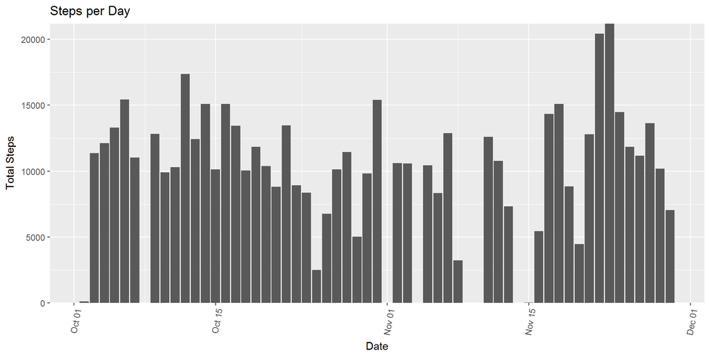

```r
ggplot(data = activity, aes(date, steps)) +
  stat_summary(fun.y = sum, geom = "bar") +
  theme(axis.text.x=element_text(angle=80, hjust=1)) +
  ggtitle("Steps per Day") +
  xlab("Date") +
  ylab("Total Steps") +
  scale_y_continuous(expand = c(0, 0))
```

### Mean and median number of steps taken each day

Output a table of the mean and mediam number of steps taken per day. Uses the summarise function from dplyr.

```r
activity_summary <- activity %>%
  group_by(date) %>%
  summarise (Mean = mean(steps, na.rm = TRUE), Median = median(steps, na.rm = TRUE))
format(activity_summary)
```

```
##          date       Mean Median
## 1  2012-10-01        NaN     NA
## 2  2012-10-02  0.4375000      0
## 3  2012-10-03 39.4166667      0
## 4  2012-10-04 42.0694444      0
## 5  2012-10-05 46.1597222      0
## 6  2012-10-06 53.5416667      0
## 7  2012-10-07 38.2465278      0
## 8  2012-10-08        NaN     NA
## 9  2012-10-09 44.4826389      0
## 10 2012-10-10 34.3750000      0
## 11 2012-10-11 35.7777778      0
## 12 2012-10-12 60.3541667      0
## 13 2012-10-13 43.1458333      0
## 14 2012-10-14 52.4236111      0
```

[output cut: 47 more lines]

Note that the median shows as zero due to the large number of 5 minute intervals with no steps

## What is the average daily activity pattern?

Output a time plot of the average number of steps taken (per interval)

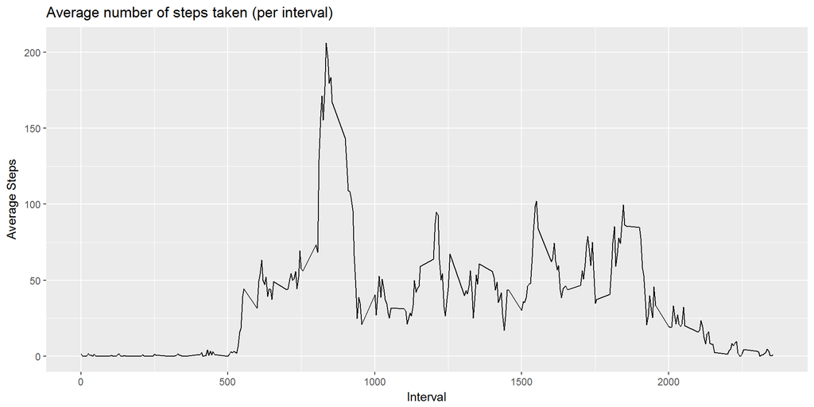

```r
interval_summary <- activity %>%
  group_by(interval) %>%
  summarise (Mean = mean(steps, na.rm = TRUE))

ggplot(data = interval_summary, mapping = aes(x = interval, y = Mean)) +
  geom_line() +
  ggtitle("Average number of steps taken (per interval)") +
  xlab("Interval") +
  ylab("Average Steps")
```

### The 5-minute interval that, on average, contains the maximum number of steps

```r
max_interval <- interval_summary[which.max( interval_summary$Mean ),]
format(max_interval)
```

```
##   interval     Mean
## 1      835 206.1698
```

The interval with the highest mean is 835 with an average of 206.1698113 steps

## Imputing missing values

The NA value will be replaced with the average of the interval

```r
totalna <- sum( is.na( activity$steps ) )

impute.mean <- function(x) {
  replace(x, is.na(x), mean(x, na.rm = TRUE))
}

activity_imputed <- activity %>%
  group_by(interval) %>%
  mutate(
    steps = impute.mean(steps)
  )

summary(activity_imputed)
```

```
##      steps             date               interval
##  Min.   :  0.00   Min.   :2012-10-01   Min.   :   0.0
##  1st Qu.:  0.00   1st Qu.:2012-10-16   1st Qu.: 588.8
##  Median :  0.00   Median :2012-10-31   Median :1177.5
##  Mean   : 37.38   Mean   :2012-10-31   Mean   :1177.5
##  3rd Qu.: 27.00   3rd Qu.:2012-11-15   3rd Qu.:1766.2
##  Max.   :806.00   Max.   :2012-11-30   Max.   :2355.0
```

There were 2304 values replaced with the mean for that period

### Histogram of the total number of steps taken each day after missing values are imputed

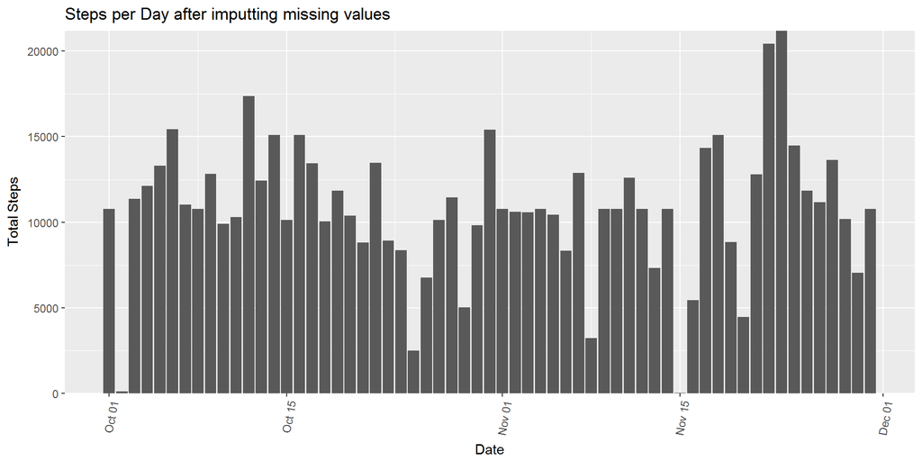

```r
ggplot(data = activity_imputed, aes(date, steps)) +
  stat_summary(fun.y = sum, geom = "bar") +
  theme(axis.text.x=element_text(angle=80, hjust=1)) +
  ggtitle("Steps per Day after imputting missing values") +
  xlab("Date") +
  ylab("Total Steps") +
  scale_y_continuous(expand = c(0, 0))
```

### Mean and median total number of steps taken per day after missing values are imputed

```r
activity_imputed_summary <- activity_imputed %>%
  group_by(date) %>%
  summarise (Mean = mean(steps, na.rm = TRUE), Median = median(steps, na.rm = TRUE))
format(activity_imputed_summary)
```

```
##          date       Mean   Median
## 1  2012-10-01 37.3825996 34.11321
## 2  2012-10-02  0.4375000  0.00000
## 3  2012-10-03 39.4166667  0.00000
## 4  2012-10-04 42.0694444  0.00000
## 5  2012-10-05 46.1597222  0.00000
## 6  2012-10-06 53.5416667  0.00000
## 7  2012-10-07 38.2465278  0.00000
## 8  2012-10-08 37.3825996 34.11321
## 9  2012-10-09 44.4826389  0.00000
## 10 2012-10-10 34.3750000  0.00000
## 11 2012-10-11 35.7777778  0.00000
## 12 2012-10-12 60.3541667  0.00000
## 13 2012-10-13 43.1458333  0.00000
## 14 2012-10-14 52.4236111  0.00000
```

[output cut: 47 more lines]

## Are there differences in activity patterns between weekdays and weekends?

Panel plot comparing the average number of steps taken per 5-minute interval across weekdays and weekends

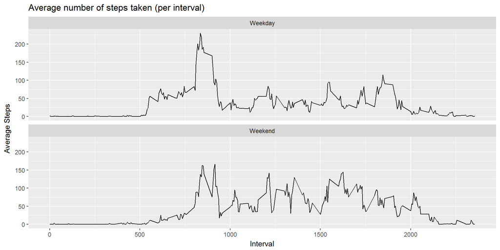

```r
activity_imputed$weekday <- ifelse(isWeekday(activity_imputed$date, wday=1:5), "Weekday", "Weekend")

interval_imputed_summary <- activity_imputed %>%
  group_by(interval, weekday) %>%
  summarise (Mean = mean(steps, na.rm = TRUE))

ggplot(data = interval_imputed_summary, mapping = aes(x = interval, y = Mean)) +
  geom_line() +
  facet_wrap(~weekday, ncol=1)+
  ggtitle("Average number of steps taken (per interval)") +
  xlab("Interval") +
  ylab("Average Steps")
```

While the graphs both follow similar trends, there are clear differnces between the weekdays and the weekend